# supplement 6

Steve Simon

May 20, 2018

This file creates various formulas and graphs needed to illustrate the underlying theory behind the data analyses in survival-lecture-6.Rmd. I am sharing this for those who are curious, but you are not responsible for learning or using the code shown in this supplement.

This file does not need any special libraries other than the ones listed below. Many of the data sets in this program use data from Hosmer, Lemeshow, and May.

```r
library(broom)
library(dplyr)
```

```r
library(ggplot2)
library(magrittr)
library(survival)
library(tidyr)
```

## The Kaplan-Meier plot and proportional hazards.

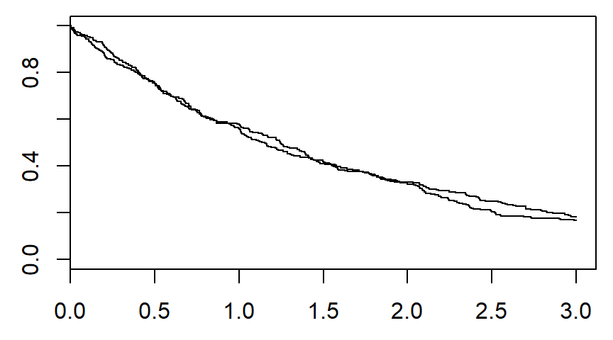

```r
par(mar=c(2.6, 2.6, 0.6, 0.6))
n <- 300
t1 <- rexp(n, 0.6)
t2 <- rexp(n, 0.6)
censor <- as.numeric(c(t1, t2) < 3)
eq <- data.frame(
  time=pmin(c(t1, t2), 3),
  gp=rep(1:2, each=n),
  censor=censor)
eq_surv <- Surv(eq$time, eq$censor)
plot(survfit(eq_surv~eq$gp))
```

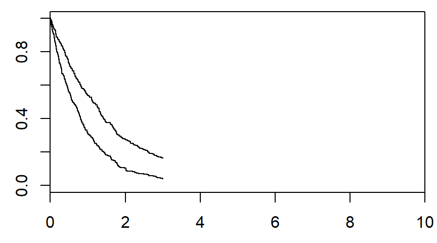

```r
par(mar=c(2.6, 2.6, 0.6, 0.6))
n <- 300
t1 <- rexp(n, 0.6)
t2 <- rexp(n, 1.2)
censor <- as.numeric(c(t1, t2) < 3)
div03 <- data.frame(
  time=pmin(c(t1, t2), 3),
  gp=rep(1:2, each=n),
  censor=censor)
div03_surv <- Surv(div03$time, div03$censor)
plot(survfit(div03_surv~div03$gp), xlim=c(0,10))
```

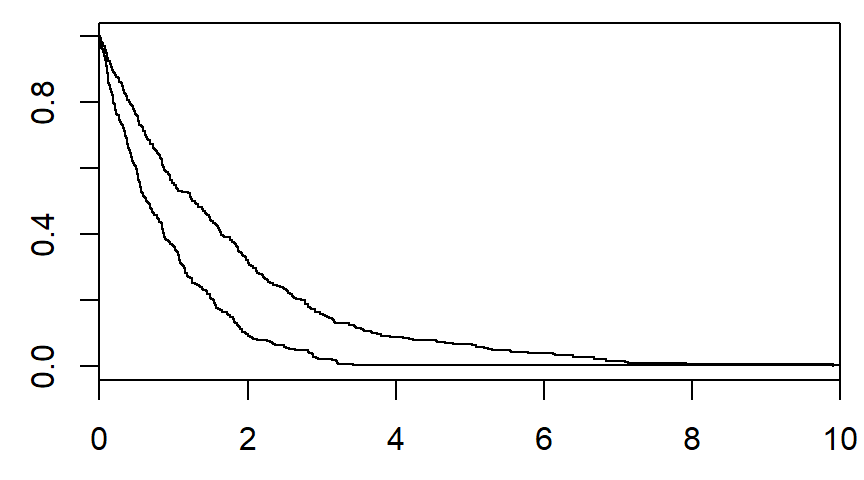

```r
par(mar=c(2.6, 2.6, 0.6, 0.6))
n <- 300
t1 <- rexp(n, 0.6)
t2 <- rexp(n, 1.2)
t1[1] <- 9.9
t2[1] <- 9.9
censor <- as.numeric(c(t1, t2) < 10)
div10 <- data.frame(
  time=pmin(c(t1, t2), 10),
  gp=rep(1:2, each=n),
  censor=censor)
div10_surv <- Surv(div10$time, div10$censor)
plot(survfit(div10_surv~div10$gp), xlim=c(0,10))
```

A key and very important deviation from proportional hazards is when one group has increased hazard early and a second group has increased hazard late. The Kaplan-Meier curves for the two groups will show this if they cross.

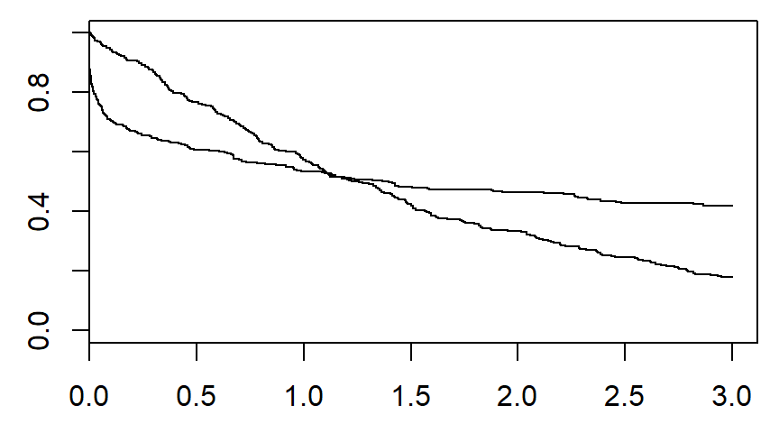

```r
par(mar=c(2.6, 2.6, 0.6, 0.6))
n <- 300
t1 <- rexp(n, 0.6)
t2 <- rgamma(n, 0.2, 0.02)
censor <- as.numeric(c(t1, t2) < 3)
cross <- data.frame(
  time=pmin(c(t1, t2), 3),
  gp=rep(1:2, each=n),
  censor=censor)
cross_surv <- Surv(cross$time, cross$censor)
plot(survfit(cross_surv~cross$gp))
```

## Complementary log-log plot

If the proportional hazards assumption holds then the survival curves for two different groups should be related by

$S_2(t) = S_1(t)^{hr}$

Take the logarithm of both sides to get

$log(S_2(t)) = log(S_1(t)) hr$

We’d like to take a second log here, but since $S_2$ and $S_1$ are always between 0 and 1, their logarithms would be negative. You have to flip this to a positive value and then take a second logarithm.

$log(-log(S_2(t))) = log(-log(S_1(t))) + log(hr)$

If this transformation, the complementary log-log transformation, produces two curves that are separated by a constant for all values of t, then you have evidence to support the proportional hazards assumption.

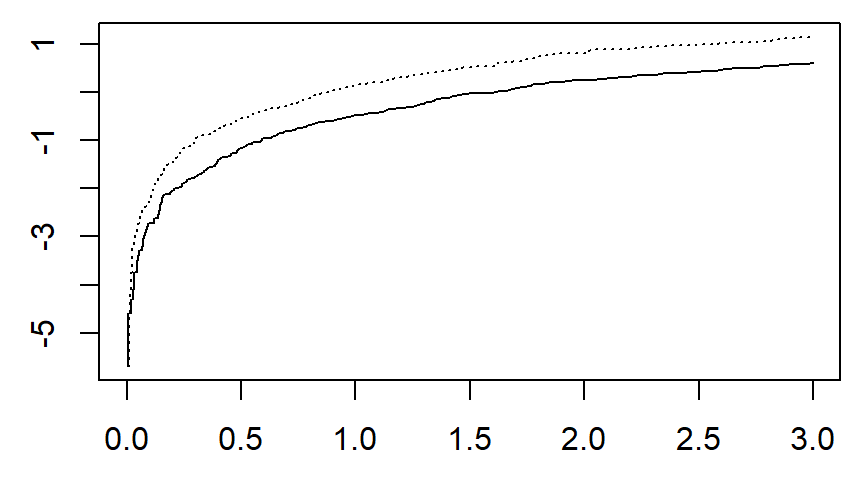

```r
par(mar=c(2.6, 2.6, 0.6, 0.6))
div03_km <- survfit(div03_surv~div03$gp)
g1 <- 1:div03_km$strata[1]
g2 <- (div03_km$strata[1]+1):sum(div03_km$strata)
plot(
  div03_km$time,
  log(-log(div03_km$surv)),
  type="n")
lines(
  div03_km$time[g2],
  log(-log(div03_km$surv[g2])),
  type="s", lty="dotted")
lines(
  div03_km$time[g1],
  log(-log(div03_km$surv[g1])),
  type="s")
```

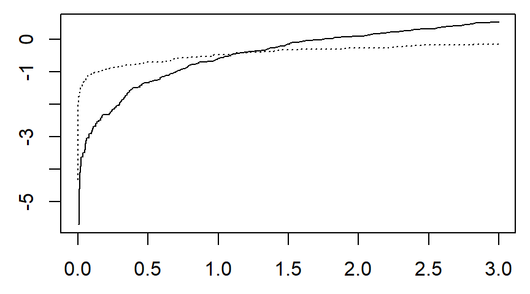

```r
par(mar=c(2.6, 2.6, 0.6, 0.6))
cross_km <- survfit(cross_surv~cross$gp)
g1 <- 1:cross_km$strata[1]
g2 <- (cross_km$strata[1]+1):sum(cross_km$strata)
plot(
  cross_km$time,
  log(-log(cross_km$surv)),
  type="n")
lines(
  cross_km$time[g2],
  log(-log(cross_km$surv[g2])),
  type="s", lty="dotted")
lines(
  cross_km$time[g1],
  log(-log(cross_km$surv[g1])),
  type="s")
```

## Review the likelihood ratio test

The partial likelihood is

$l_p = \prod_i \frac{e^{X_{(i)} \beta}}{\sum_{j \in R_{(i)}} e^{X_{j}\beta}}$

The log partial likelihood is

$L_p=\sum_i \big( X_{(i)} \beta - log(\sum_{j \in R_{(i)}} e^{X_j \beta}) \big)$

The derivative of the log partial likelihood is

$\frac{\partial L_p}{\partial \beta}= \sum\limits_{i=1}^m \big( X_{(i)} - \bar{X}_i(\beta) \big)$

where $\bar{X}_i(\beta)$ is a weighted average of all the X’s remaining in the risk set and with weights equal to

$w_{ij}=\frac{e^{X_j \beta}}{\sum_{l \in R_i} e^{X_l \beta}}$.

A positive derivative implies that we could maximize the log partial likelihood by increasing from the current value of $\beta$ and a negative derivative implies the opposite.

## Schoenfeld residuals.

The slope of the likelihood function is zero at its maximum, which implies that

$\sum\limits_{i=1}^m \big( X_{(i)} - \bar{X}_i(\hat{\beta}) \big) = 0$.

The individual terms in this sum,

$X_{(i)} - \bar{X}_i(\hat{\beta})$,

are called the Schoenfeld residuals.

Normally, the Schoenfeld residuals are standardized. If you see a time trend with respect to the Schoenfeld residuals, then this is evidence of a violation of the proportional hazards assumption.

If the Schoenfeld residuals show a positive time trend (negative early and positive late), that means that you have a hazard ratio that is a bit too large early and a bit too small late.

## Stratified analysis

If one of the variables in your model is a nuisance variable, but it could possibly be the cause of the violation of the proportional hazards assumption, you can fit fix this by fitting a separate baseline hazard for each level of your nuisance variable.

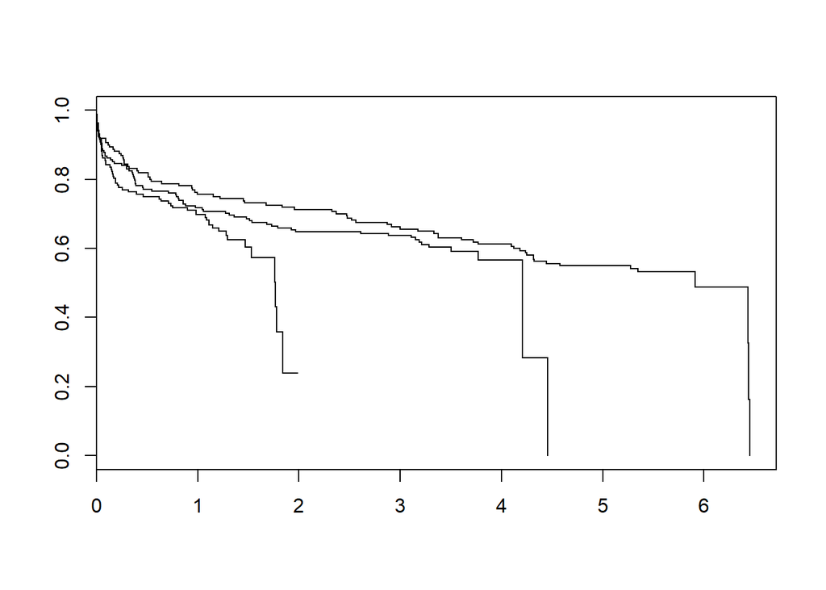

```r
fn <- "~/survival-models/bin/whas500.RData"
load(fn)
year_km <- survfit(
  Surv(whas500$time_yrs, whas500$fstat=="Dead")~whas500$year)
plot(year_km)
```

## Time-varying covariates

Page 221 of Hosmer, Lemeshow, and May describes the grace data set, which you can use for time-varying covariates.

```r
fn <- "~/survival-models/data/wiley/GRACE1000.dat"
grace <- read.table(fn, header = FALSE)
names(grace) <- c(
  "id",
  "days",
  "death",
  "revasc",
  "revascdays",
  "los",
  "age",
  "sysbp",
  "stchange")
head(grace)
```

```
##   id days death revasc revascdays los age sysbp stchange
## 1  1  180     0      0        180   9  28   107        1
## 2  2    5     0      1          0   5  32   121        1
## 3  3    2     0      0          2   2  33   150        0
## 4  4    5     0      1          2   5  35   172        0
## 5  5  180     0      1          9  10  35   106        0
## 6  6    5     0      0          5   5  34   120        0
```

## Review the likelihood ratio test

Consider a small data set with the following survival times:

1 M 6 1

2 F 14 1

3 F 44 1

4 M 45 0

5 F 89 0

6 M 98 1

7 F 99 1

8 F 104 1

9 M 114 1

the partial likelihood ratio is

$l_p = \prod_i \frac{\psi_{(i)}}{\sum_{j \in R_{(i)}} \psi_j}$

where the parentheses around the subscript implicitly excludes those patients who were censored,

$\psi_{(i)} = e^{X_{(i)} \beta}$

and $R_{(i)}$ is the set of all patients at risk at time $t_{(i)}$.

For a simple case with a binary predictor like gender, you would have $\psi_{(i)}$ equalling a constant $\psi$ for females and a constant 1 for males.

It helps to keep tabs on the running number of men and women at risk at each time point.

1 M 6 1 4/5

2 F 14 1 3/5

3 F 44 1 3/4

4 M 45 0 3/3

5 F 89 0 2/3

6 M 98 1 2/2

7 F 99 1 1/2

8 F 104 1 1/1

9 M 114 1 1/0

At t=6, a male died, making the numerator 1. The denominator is 4+5$\psi$ because there are 4 males and 5 females in the risk set. The fraction is

$\frac{1}{4+5\psi}$

At t=14, a female died, making the numerator $\psi$ and the denominator is 3+5$\psi$ because there are 3 males and 5 females in the risk set. The second fraction in the product is

$\frac{\psi}{3+5\psi}$

At t=44, another female died, making the numerator $\psi$ again, but the denominator is 3+4$\psi$ because there are 3 males and 4 females in the risk set. This fraction is

$\frac{\psi}{3+4\psi}$

You skip the censored values of t=45 and t=89. The remaining fractions are

$\frac{1}{2+2\psi}$

$\frac{\psi}{1+2\psi}$

$\frac{\psi}{1+\psi}$

$\frac{1}{1}$

The entire product works out to be

$\frac{\psi^4}{(4+5\psi)(3+5\psi)(3+4\psi)(2+2\psi)(1+2\psi)(1+\psi)}$

Let’s plot this for various values of $\psi=e^\beta$.

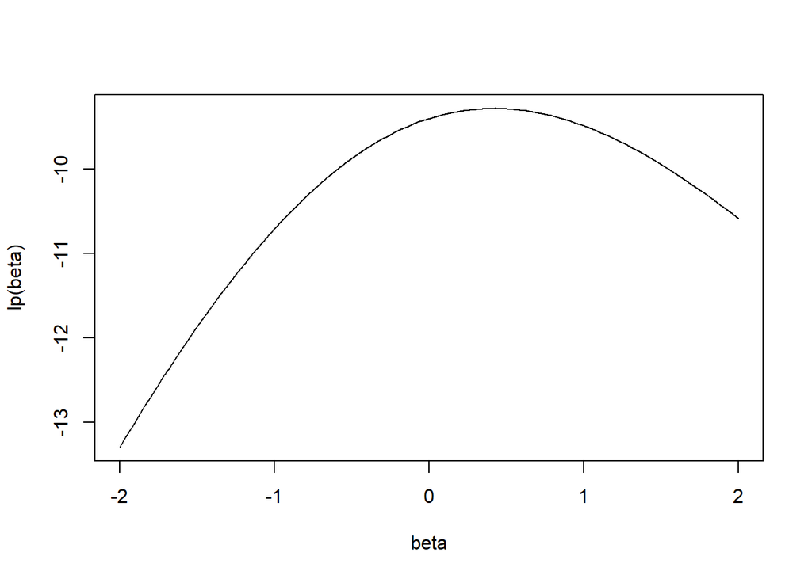

```r
lp <- function(beta) {
  psi <- exp(beta)
  f <- psi^4 /
    ((4+5*psi)*
     (3+5*psi)*
     (3+4*psi)*
     (2+2*psi)*
     (1+2*psi)*
     (1+  psi))
  return(log(f))
}
beta <- seq(-2, 2, length=100)
plot(beta, lp(beta), type="l")
```

```r
beta[which.max(lp(beta))]
```

```
## [1] 0.4242424
```

The second derivative of the log partial likelihood is

$\frac{\partial L_p}{\partial \beta}= -\sum_i \sum_{j \in R_i}{} w_{ij}\big( X_j - \bar{X}_{w{(i)}} \big)^2$

which is a weighted variance.

The information matrix is the negative of the second derivative and the inverse of the information matrix gives you the variances and covariances of the maximum likelihood estimates.

## Also for discussion

- Stratified analysis. Stratify whas500 by year=1, 2, 3. This would use the actg320 data. Compare output to Table 7.1.

Save everything for possible later re-use.

```r
save.image("~/survival-models/bin/supplement-6.RData")
```